# Attitudes towards outreach in particle physics

Achintya Rao

26 April 2016

# Conclusions

# Outreach activities

- Most respondents to survey have participated in outreach in the past
  - F/M ratio ~same
- Most said they will participate in the coming 12 months

# Attitudes to specific groups

- Colleagues — most important, most knowledgeable, easiest to communicate with
- Science journalists, school students, non-specialist public on par for importance and for ease of communication
- Science journalists more knowledgeable than students and public

# A bit about me

- **Science Communicator** (2010 — present)  
  Compact Muon Solenoid (CMS) Collaboration at CERN
- **Doctoral Student** (2014 — present)  
  UWE Science Communication Unit, Bristol
  - **MA in Science Journalism** (2009 — 2010)  
    City University, London
  - **BSc in Physics** (2005 — 2008)  
    St. Xavier’s College, Mumbai (Bombay)

Twitter: [@RaoOfPhysics](https://twitter.com/RaoOfPhysics) | GitHub: [@RaoOfPhysics](https://github.com/RaoOfPhysics)  
This presentation: github.com/RaoOfPhysics/201604_PCST

# Public engagement

- Conversation dominated with research fields that have:
  - direct impact
  - immediate impact
- What about fundamental research?

# My PhD project

# “Engagement” → “Outreach”

- used to refer to all science-communication activities “designed for an audience outside academia” (Crettaz von Roten, 2011, p.54)
- used among particle physicists to refer to:
  - working with schools
  - direct dialogue with the public
  - disseminating information through the media

> The term “outreach” refers to all science communication and education activities that bring scientific research to audiences outside the research community. It is also known as “popularisation”.

— note included in survey

# Research questions

- What are the attitudes towards outreach within the particle-physics community and what are the motivations for and barriers against participating
- Do these vary w.r.t. age, gender and academic position

# Research questions (…)

- How are these influenced by
  - funding bodies
  - national expectations towards outreach
  - the multicultural nature of international collaborations
- How does the community perceive the usefulness and impact of outreach

### [CERN](http://home.cern)

The European Laboratory for Particle Physics

- Geneva, Switzerland
- host laboratory for international collaborations
- ~half of all 20,000 particle physicists

### The CMS Collaboration

[**C**ompact **M**uon **S**olenoid](http://cms.web.cern.ch)

- one of the two teams that [discovered the Higgs boson in 2012](http://cms.web.cern.ch/news/observation-new-particle-mass-125-gev)
- people (June 2015)
  - over 4000 physicists, engineers, students (not including technicians and admin)
  - 183 institutes, universities, laboratories from 42 countries
  - 80+ nationalities

# Data collection for quantitative analysis

# Electronic survey distributed by e-mail

- Sent to the whole collaboration via mailing list
- Three reminders sent to whole list
- Engineers reminded separately as well
- Representatives from low-response countries reminded separately

# Responses

- over 400, but a few duplicates
- final count: **391** valid responses
- ~10% of the collaboration

# CMS member countries

[interactive chart not shown]

# Gender

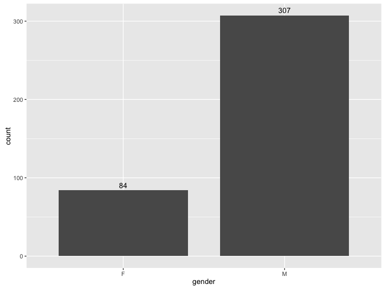

# Age

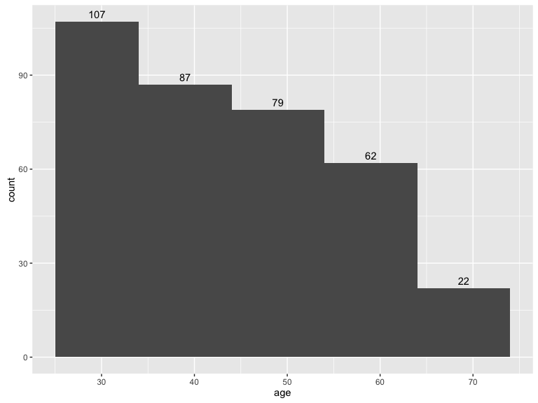

# Participation in outreach

# Previous participation

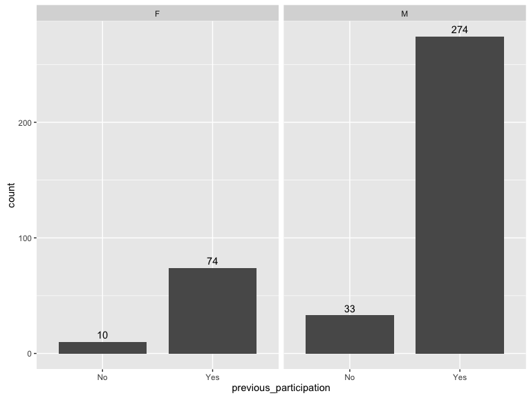

# Last 12 months

Total no. of activities → Time spent on outreach

[figure not shown]

# Next 12 months?

Past → Future

[figure not shown]

# Attitudes towards specific groups

**Importance**

> How important it is for you, personally, to communicate your research with the following groups

| 1 | 2 | 3 | 4 | 5 |
| --- | --- | --- | --- | --- |
| Not important at all |  |  |  | Very important |

**Knowledge**

> How knowledgeable do you think each group, as a whole, is about your research area

| 1 | 2 | 3 | 4 | 5 |
| --- | --- | --- | --- | --- |
| Not knowledgeable at all |  |  |  | Very knowledgeable |

**Ease**

> How easy it is for you to talk about your research with these groups

| 1 | 2 | 3 | 4 | 5 |
| --- | --- | --- | --- | --- |
| Very difficult |  |  |  | Very easy |

| 1 | 2 | 3 | 4 | 5 |
| --- | --- | --- | --- | --- |
| Not “favourable” |  |  |  | “Favourable” |

# Groups

**Colleagues** · Other scientists · Press officers  
Teachers · University students · **School students**  
General journalists · **Science journalists** · Other media  
Politicians · Industry · **Non-specialist public**

# Colleagues

[interactive chart not shown]

# Students

[interactive chart not shown]

# Science Journalists

[interactive chart not shown]

# Non-specialist public

[interactive chart not shown]

# Importance

[interactive chart not shown]

# Importance (…)

Colleagues → Students → SciJournos → NSP

[figure not shown]

# Knowledge

[interactive chart not shown]

# Knowledge (…)

Colleagues → Students → SciJournos → NSP

[figure not shown]

# Ease

[interactive chart not shown]

# Ease (…)

Colleagues → Students → SciJournos → NSP

[figure not shown]

# Conclusions

# Outreach activities

- Most respondents to survey have participated in outreach in the past
  - F/M ratio ~same
- Most said they will participate in the coming 12 months

# Attitudes to specific groups

- Colleagues — most important, most knowledgeable, easiest to communicate with
- Science journalists, school students, non-specialist public on par for importance and for ease of communication
- Science journalists more knowledgeable than students and public

# Acknowledgements

Emma Weitkamp, Clare Wilkinson, Erik Stengler, Christine Sutton, for supervising my research

Achille Petrilli, CMS Head of Communications, for supporting my research

Special thanks to Richard Smith-Unna (t: [@blahah404](https://twitter.com/blahah404)) for help with R code!

[R](https://www.r-project.org/) + [RStudio](https://www.rstudio.com/)

[reveal.js](http://lab.hakim.se/reveal-js/)

[plotly](https://plot.ly/)

[RAW](http://raw.densitydesign.org/)

[Git](https://git-scm.com/) + [GitHub](https://github.com/)